# Project Foundations for Data Science: FoodHub Data Analysis

**Marks: 40**

### Context

The number of restaurants in New York is increasing day by day. Lots of students and busy professionals rely on those restaurants due to their hectic lifestyles. Online food delivery service is a great option for them. It provides them with good food from their favorite restaurants. A food aggregator company FoodHub offers access to multiple restaurants through a single smartphone app.

The app allows the restaurants to receive a direct online order from a customer. The app assigns a delivery person from the company to pick up the order after it is confirmed by the restaurant. The delivery person then uses the map to reach the restaurant and waits for the food package. Once the food package is handed over to the delivery person, he/she confirms the pick-up in the app and travels to the customer's location to deliver the food. The delivery person confirms the drop-off in the app after delivering the food package to the customer. The customer can rate the order in the app. The food aggregator earns money by collecting a fixed margin of the delivery order from the restaurants.

### Objective

The food aggregator company has stored the data of the different orders made by the registered customers in their online portal. They want to analyze the data to get a fair idea about the demand of different restaurants which will help them in enhancing their customer experience. Suppose you are hired as a Data Scientist in this company and the Data Science team has shared some of the key questions that need to be answered. Perform the data analysis to find answers to these questions that will help the company to improve the business.

### Data Description

The data contains the different data related to a food order. The detailed data dictionary is given below.

### Data Dictionary

- order_id: Unique ID of the order
- customer_id: ID of the customer who ordered the food
- restaurant_name: Name of the restaurant
- cuisine_type: Cuisine ordered by the customer
- cost: Cost of the order
- day_of_the_week: Indicates whether the order is placed on a weekday or weekend (The weekday is from Monday to Friday and the weekend is Saturday and Sunday)
- rating: Rating given by the customer out of 5
- food_preparation_time: Time (in minutes) taken by the restaurant to prepare the food. This is calculated by taking the difference between the timestamps of the restaurant's order confirmation and the delivery person's pick-up confirmation.
- delivery_time: Time (in minutes) taken by the delivery person to deliver the food package. This is calculated by taking the difference between the timestamps of the delivery person's pick-up confirmation and drop-off information

### Let us start by importing the required libraries

```python
# import libraries for data manipulation
import numpy as np
import pandas as pd

# import libraries for data visualization
import matplotlib.pyplot as plt
import seaborn as sns
```

### Understanding the structure of the data

```python
# uncomment and run the following lines for Google Colab
from google.colab import drive
drive.mount('/content/drive')
```

```python
# read the data
df = pd.read_csv('/content/drive/MyDrive/MIT projects/foodhub_order.csv')
# returns the first 5 rows
df.head()
```

|  | order_id | customer_id | restaurant_name | cuisine_type | cost_of_the_order | day_of_the_week | rating | food_preparation_time | delivery_time |
| --- | --- | --- | --- | --- | --- | --- | --- | --- | --- |
| 0 | 1477147 | 337525 | Hangawi | Korean | 30.75 | Weekend | Not given | 25 | 20 |
| 1 | 1477685 | 358141 | Blue Ribbon Sushi Izakaya | Japanese | 12.08 | Weekend | Not given | 25 | 23 |
| 2 | 1477070 | 66393 | Cafe Habana | Mexican | 12.23 | Weekday | 5 | 23 | 28 |
| 3 | 1477334 | 106968 | Blue Ribbon Fried Chicken | American | 29.20 | Weekend | 3 | 25 | 15 |
| 4 | 1478249 | 76942 | Dirty Bird to Go | American | 11.59 | Weekday | 4 | 25 | 24 |

#### Observations:

The DataFrame has 9 columns as mentioned in the Data Dictionary. Data in each row corresponds to the order placed by a customer.

### **Question 1:** How many rows and columns are present in the data?

```python
# Overview of the dataset shape and datatypes
print("Dataset Shape (Rows, Columns):", df.shape)
```

```
Dataset Shape (Rows, Columns): (1898, 9)
```

#### Observations:There are 1898 rows and 9 columns.

### **Question 2:** What are the datatypes of the different columns in the dataset? (The info() function can be used)

```python
df.info()
```

```
<class 'pandas.core.frame.DataFrame'>
RangeIndex: 1898 entries, 0 to 1897
Data columns (total 9 columns):
 #   Column                 Non-Null Count  Dtype
---  ------                 --------------  -----
 0   order_id               1898 non-null   int64
 1   customer_id            1898 non-null   int64
 2   restaurant_name        1898 non-null   object
 3   cuisine_type           1898 non-null   object
 4   cost_of_the_order      1898 non-null   float64
 5   day_of_the_week        1898 non-null   object
 6   rating                 1898 non-null   object
 7   food_preparation_time  1898 non-null   int64
 8   delivery_time          1898 non-null   int64
dtypes: float64(1), int64(4), object(4)
memory usage: 133.6+ KB
```

#### Observations:There are 1 column that's a float, 4 columns of integers, and 4 columns of objects.

### **Question 3:** Are there any missing values in the data? If yes, treat them using an appropriate method

```python
df.isnull().sum()
```

|  | 0 |
| --- | --- |
| order_id | 0 |
| customer_id | 0 |
| restaurant_name | 0 |
| cuisine_type | 0 |
| cost_of_the_order | 0 |
| day_of_the_week | 0 |
| rating | 0 |
| food_preparation_time | 0 |
| delivery_time | 0 |

**dtype:** int64

#### Observations: There appears to be no missing values in the data. However we know there are "Not given" values for the rating column. As we will be using these missing values in the project we will leave them for now.

```python
# Replace 'Not given' with NaN to handle missing values
#df['rating'] = pd.to_numeric(df['rating'], errors='coerce')

# Check the proportion of missing values
#missing_ratings = df['rating'].isnull().sum()
#print(f"Missing Ratings: {missing_ratings}")
#Will return 'Missing Ratings: 736'
#print(f"Proportion of Missing Ratings: {missing_ratings / len(df):.2%}")
#Will return 'Proportion of Missing Ratings: 38.78%'
```

### **Question 4:** Check the statistical summary of the data. What is the minimum, average, and maximum time it takes for food to be prepared once an order is placed?

```python
df.describe()
```

|  | order_id | customer_id | cost_of_the_order | food_preparation_time | delivery_time |
| --- | --- | --- | --- | --- | --- |
| count | 1.898000e+03 | 1898.000000 | 1898.000000 | 1898.000000 | 1898.000000 |
| mean | 1.477496e+06 | 171168.478398 | 16.498851 | 27.371970 | 24.161749 |
| std | 5.480497e+02 | 113698.139743 | 7.483812 | 4.632481 | 4.972637 |
| min | 1.476547e+06 | 1311.000000 | 4.470000 | 20.000000 | 15.000000 |
| 25% | 1.477021e+06 | 77787.750000 | 12.080000 | 23.000000 | 20.000000 |
| 50% | 1.477496e+06 | 128600.000000 | 14.140000 | 27.000000 | 25.000000 |
| 75% | 1.477970e+06 | 270525.000000 | 22.297500 | 31.000000 | 28.000000 |
| max | 1.478444e+06 | 405334.000000 | 35.410000 | 35.000000 | 33.000000 |

#### Observations: Based on the 'food_preparation_time' column, the minimum is 20 min, the average is 27.371970 min, and the max is 35 min.

### **Question 5:** How many orders are not rated?

```python
df['rating'].value_counts()
```

| rating | count |
| --- | --- |
| Not given | 736 |
| 5 | 588 |
| 4 | 386 |
| 3 | 188 |

**dtype:** int64

#### Observations: 736 orders are not rated.

### Exploratory Data Analysis (EDA)

### **Question 6:** Explore all the variables and provide observations on their distributions. (Generally, histograms, boxplots, countplots, etc. are used for univariate exploration)

```python
# Check unique order ID
df.nunique()
```

|  | 0 |
| --- | --- |
| order_id | 1898 |
| customer_id | 1200 |
| restaurant_name | 178 |
| cuisine_type | 14 |
| cost_of_the_order | 312 |
| day_of_the_week | 2 |
| rating | 4 |
| food_preparation_time | 16 |
| delivery_time | 19 |

**dtype:** int64

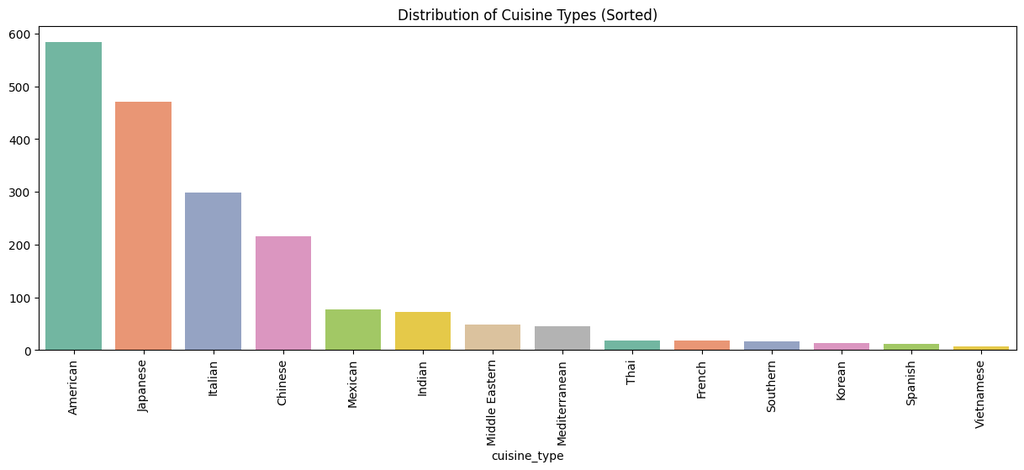

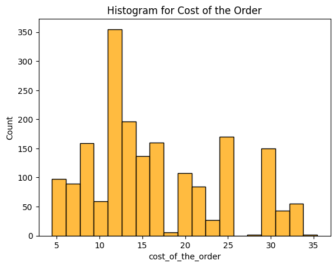

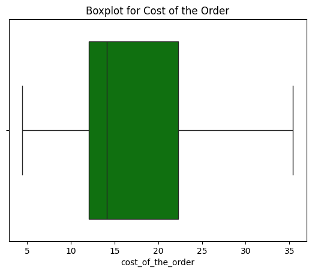

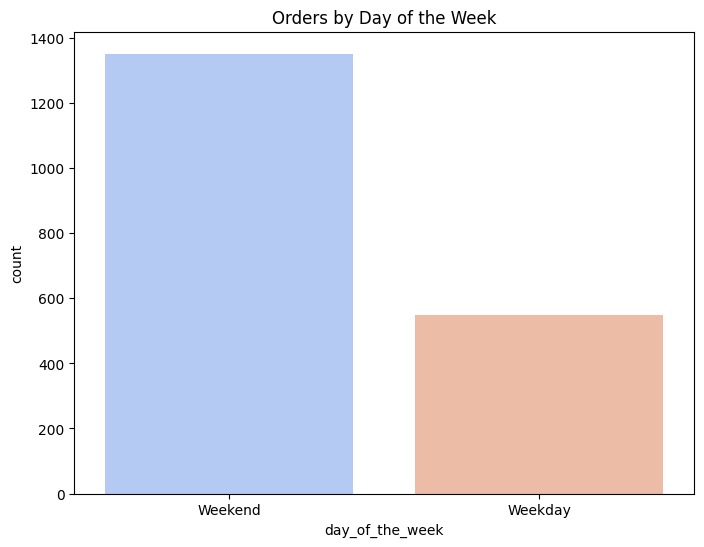

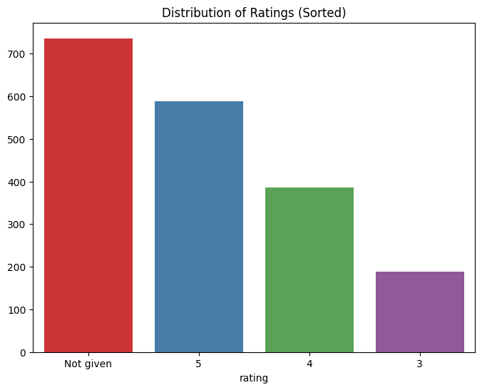

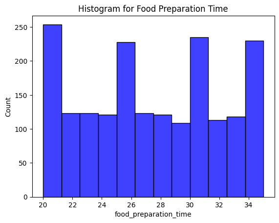

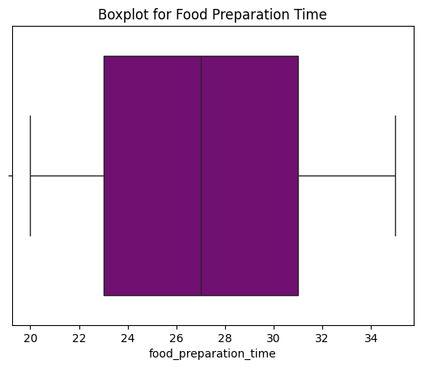

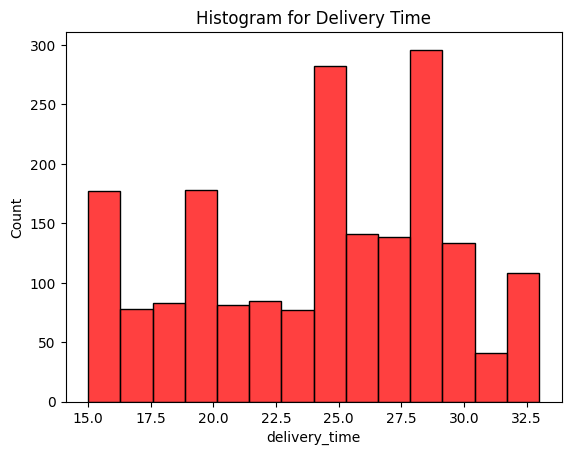

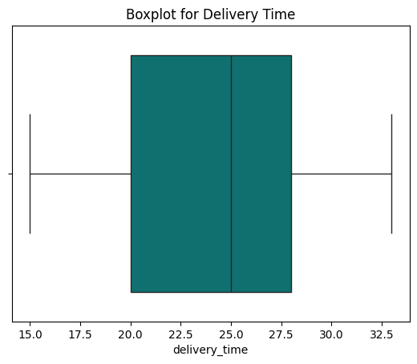

```python
import warnings
warnings.filterwarnings("ignore")

# Cuisine Types distribution sorted
plt.figure(figsize=(15, 5))
cuisine_counts = df['cuisine_type'].value_counts()
sns.barplot(x=cuisine_counts.index, y=cuisine_counts.values, palette='Set2')
plt.title('Distribution of Cuisine Types (Sorted)')
plt.xticks(rotation=90)
plt.show()

# Histogram for cost of the order
sns.histplot(data=df, x='cost_of_the_order', color='orange')
plt.title('Histogram for Cost of the Order')
plt.show()

# Boxplot for cost of the order
sns.boxplot(data=df, x='cost_of_the_order', color='green')
plt.title('Boxplot for Cost of the Order')
plt.show()

# Countplot for day of the week
plt.figure(figsize = (8,6))
sns.countplot(data = df, x = 'day_of_the_week', palette='coolwarm')
plt.title('Orders by Day of the Week')
plt.show()

# Countplot for rating
plt.figure(figsize=(8,6))
rating_counts = df['rating'].value_counts()
sns.barplot(x=rating_counts.index, y=rating_counts.values, palette='Set1')
plt.title('Distribution of Ratings (Sorted)')
plt.show()

# Histogram for food preparation time
sns.histplot(data=df, x='food_preparation_time', color='blue')
plt.title('Histogram for Food Preparation Time')
plt.show()
# Boxplot for food preparation time
sns.boxplot(data=df, x='food_preparation_time', color='purple')
plt.title('Boxplot for Food Preparation Time')
plt.show()

# Histogram for delivery time
sns.histplot(data=df, x='delivery_time', color='red')
plt.title('Histogram for Delivery Time')
plt.show()
# Boxplot for delivery time
sns.boxplot(data=df, x='delivery_time', color='teal')
plt.title('Boxplot for Delivery Time')
plt.show()
```

#### Observations:

Cuisine Type: The most popular types are "American," "Japanese," "Italian," and "Chinese," which have the highest frequency. These cuisines dominate the dataset in terms of customer preferences.

Cost of the Order: The histogram confirms a right-skewed distribution, with most orders costing below 15 dollars, as shown by the boxplot and descriptive statistics (50th percentile or median is $14.14). This supports the observation that the majority of orders are on the lower cost spectrum.

Day of the Week: As expected, people tend to eat out more on weekends, which is reflected in the count plot for the day of the week, showing a higher frequency of orders on weekends compared to weekdays.

Ratings: The highest frequency of ratings is "Not given," followed by 5, 4, and 3. This suggests that many customers don't leave ratings, but when they do, they tend to give positive feedback (5 being the most common numeric rating).

### **Question 7**: Which are the top 5 restaurants in terms of the number of orders received?

```python
top_5_restaurants=df['restaurant_name'].value_counts().head(5)
print(top_5_restaurants)
```

```
restaurant_name
Shake Shack                  219
The Meatball Shop            132
Blue Ribbon Sushi            119
Blue Ribbon Fried Chicken     96
Parm                          68
Name: count, dtype: int64
```

#### Observations: The top 5 restaurants in terms of the number of orders received seem to drop from the high bar set at 219 down to 68 rather fast. My guess is that the data for orders received by restaurant follows an exponential distribution. I will add a code block after this observation to test this theory.

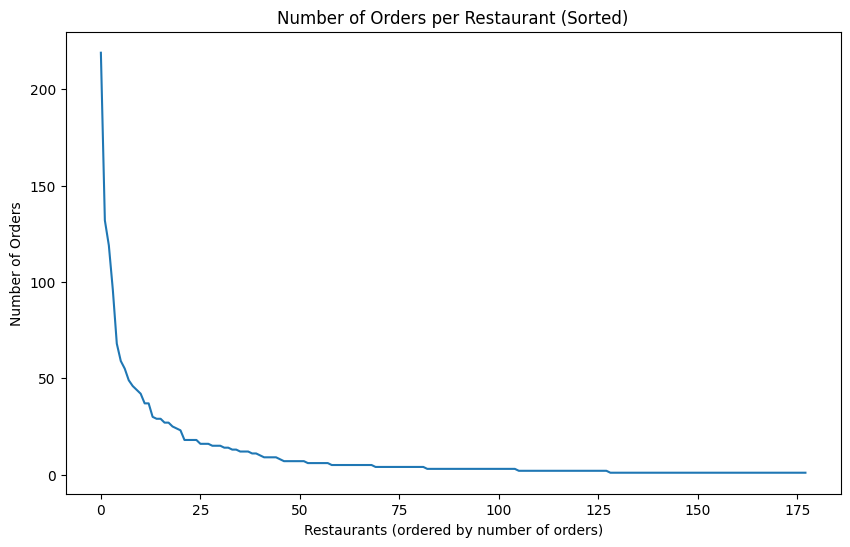

```python
# Plotting the number of orders for each restaurant, ordered by count
plt.figure(figsize=(10,6))
sorted_restaurants = df['restaurant_name'].value_counts().sort_values(ascending=False)

# Plotting the sorted distribution
plt.plot(sorted_restaurants.values)
plt.title('Number of Orders per Restaurant (Sorted)')
plt.xlabel('Restaurants (ordered by number of orders)')
plt.ylabel('Number of Orders')
plt.show()
```

### **Question 8**: Which is the most popular cuisine on weekends?

```python
weekend_orders = df[df['day_of_the_week'] == 'Weekend']
weekend_orders['cuisine_type'].value_counts()
```

| cuisine_type | count |
| --- | --- |
| American | 415 |
| Japanese | 335 |
| Italian | 207 |
| Chinese | 163 |
| Mexican | 53 |
| Indian | 49 |
| Mediterranean | 32 |
| Middle Eastern | 32 |
| Thai | 15 |
| French | 13 |
| Korean | 11 |
| Southern | 11 |
| Spanish | 11 |
| Vietnamese | 4 |

**dtype:** int64

#### Observations: The most popular cuisine on weekends is American cuisine.

### **Question 9**: What percentage of the orders cost more than 20 dollars?

```python
expensive_orders = df[df['cost_of_the_order'] > 20]
percentage_expensive_orders = (len(expensive_orders) / len(df)) * 100
print(f"{percentage_expensive_orders:.2f}% of orders cost more than $20.")
```

```
29.24% of orders cost more than $20.
```

#### Observations: 29.24% of orders cost more than $20.

### **Question 10**: What is the mean order delivery time?

```python
mean_delivery_time = df['delivery_time'].mean()
print(f"The mean order delivery time is {mean_delivery_time:.2f} minutes.")
```

```
The mean order delivery time is 24.16 minutes.
```

#### Observations: It's the same mean we found from using "df.describe()"

### **Question 11:** The company has decided to give 20% discount vouchers to the top 3 most frequent customers. Find the IDs of these customers and the number of orders they placed

```python
df['customer_id'].value_counts().head(3)
```

| customer_id | count |
| --- | --- |
| 52832 | 13 |
| 47440 | 10 |
| 83287 | 9 |

**dtype:** int64

#### Observations: The top three customers are customer 52832 ordering 13 times, customer 47440 ordering 10 times, customer 83287 ordering 9 times.

### **Question 12**: Perform a multivariate analysis to explore relationships between the important variables in the dataset. (It is a good idea to explore relations between numerical variables as well as relations between numerical and categorical variables)

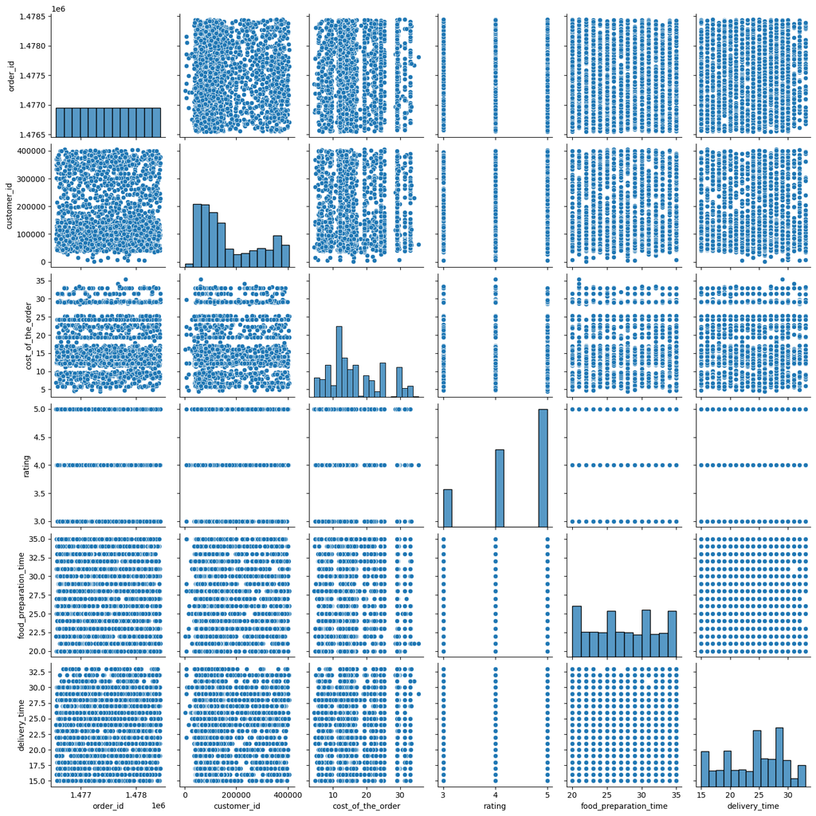

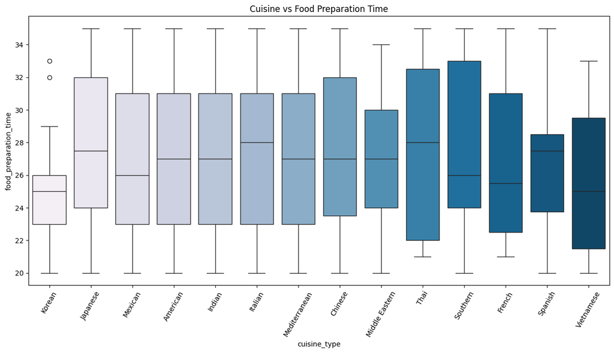

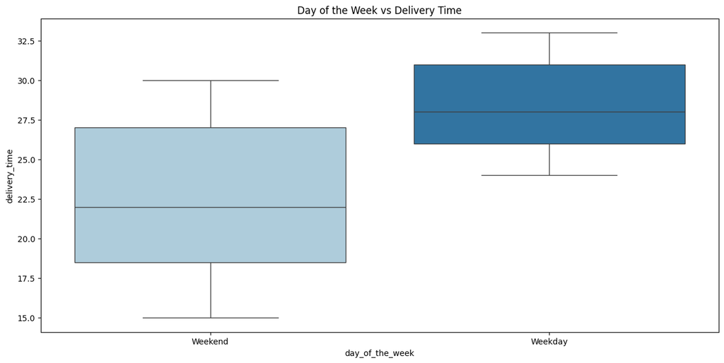

```
restaurant_name
Shake Shack                      3579.53
The Meatball Shop                2145.21
Blue Ribbon Sushi                1903.95
Blue Ribbon Fried Chicken        1662.29
Parm                             1112.76
RedFarm Broadway                  965.13
RedFarm Hudson                    921.21
TAO                               834.50
Han Dynasty                       755.29
Blue Ribbon Sushi Bar & Grill     666.62
Rubirosa                          660.45
Sushi of Gari 46                  640.87
Nobu Next Door                    623.67
Five Guys Burgers and Fries       506.47
Name: cost_of_the_order, dtype: float64
```

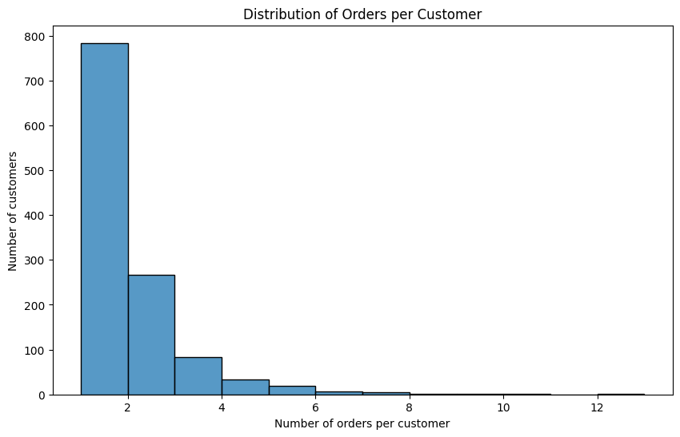

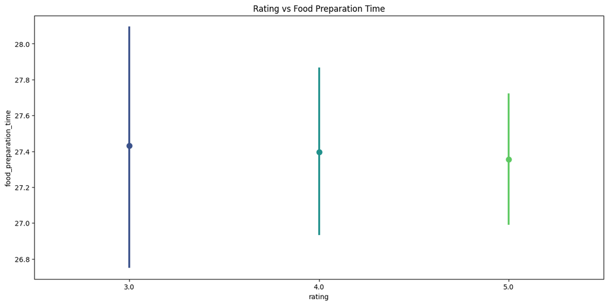

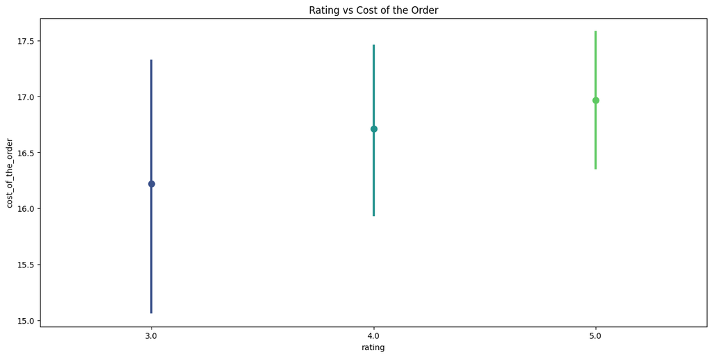

```
                       cost_of_the_order  food_preparation_time  \
cost_of_the_order               1.000000               0.041527
food_preparation_time           0.041527               1.000000
delivery_time                  -0.029949               0.011094
rating                          0.033983              -0.006083

                       delivery_time    rating
cost_of_the_order          -0.029949  0.033983
food_preparation_time       0.011094 -0.006083
delivery_time               1.000000 -0.009804
rating                     -0.009804  1.000000
```

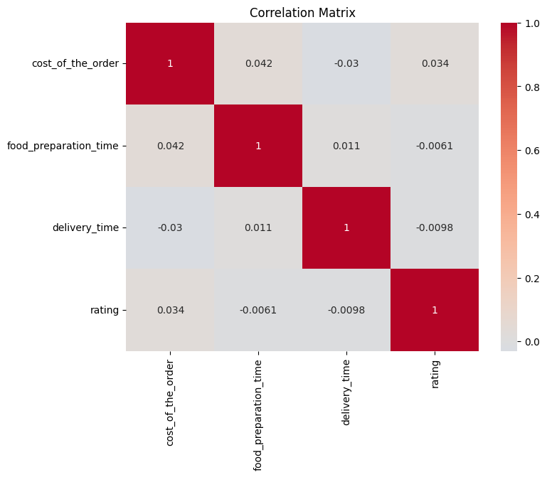

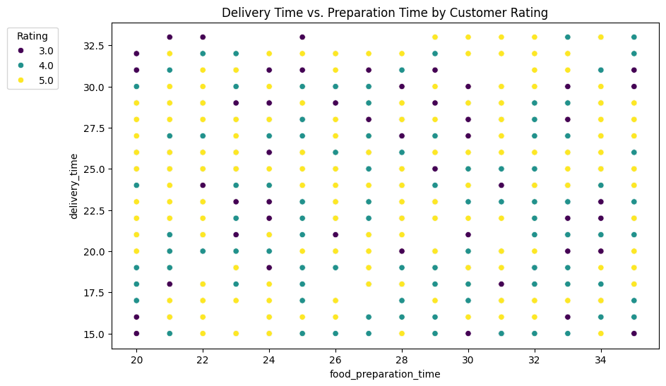

```python
df['rating'] = pd.to_numeric(df['rating'], errors='coerce')
#Pairplot
sns.pairplot(data=df)
plt.show()

# Cuisine vs Food Preparation time
plt.figure(figsize=(15,7))
sns.boxplot(x = "cuisine_type", y = "food_preparation_time", data = df, palette = 'PuBu')
plt.xticks(rotation = 60)
plt.title("Cuisine vs Food Preparation Time")
plt.show()

# Day of the Week vs Delivery time
plt.figure(figsize=(15,7))
sns.boxplot(x = "day_of_the_week", y = "delivery_time", data = df, palette = 'Paired')
plt.title("Day of the Week vs Delivery Time")
plt.show()

# Rating vs Cost of the order
restaurant_revenue = df.groupby(['restaurant_name'])['cost_of_the_order'].sum().sort_values(ascending=False).head(14)
print(restaurant_revenue)

# Assuming 'customer_id' has unique values for each customer
customer_order_counts = df['customer_id'].value_counts()
plt.figure(figsize=(10, 6))
sns.histplot(customer_order_counts, binwidth=1)
plt.xlabel("Number of orders per customer")
plt.ylabel("Number of customers")
plt.title("Distribution of Orders per Customer")
plt.show()

# Rating vs Food preparation time
plt.figure(figsize=(15, 7))
sns.pointplot(x = 'rating', y = 'food_preparation_time', data = df, palette = 'viridis')
plt.title("Rating vs Food Preparation Time")
plt.show()

# Rating vs Cost of the order
plt.figure(figsize=(15, 7))
sns.pointplot(x = 'rating', y = 'cost_of_the_order', data = df, palette = 'viridis')
plt.title("Rating vs Cost of the Order")
plt.show()

# Compute correlations between numerical variables
df['rating'] = pd.to_numeric(df['rating'], errors='coerce')
correlation_matrix = df[['cost_of_the_order', 'food_preparation_time', 'delivery_time', 'rating']].corr()
print(correlation_matrix)
# Visualize the correlation matrix
plt.figure(figsize=(8, 6))
sns.heatmap(correlation_matrix, annot=True, cmap='coolwarm', center=0)
plt.title('Correlation Matrix')
plt.show()

# Scatter plot of delivery time vs. preparation time, colored by rating
plt.figure(figsize=(10, 6))
sns.scatterplot(data=df, x='food_preparation_time', y='delivery_time', hue='rating', palette='viridis')

# Move the legend (key) to the left side
plt.legend(bbox_to_anchor=(-0.2, 1), loc='upper left', title='Rating')

plt.title('Delivery Time vs. Preparation Time by Customer Rating')
plt.show()
```

### **Question 13:** The company wants to provide a promotional offer in the advertisement of the restaurants. The condition to get the offer is that the restaurants must have a rating count of more than 50 and the average rating should be greater than 4. Find the restaurants fulfilling the criteria to get the promotional offer

```python
# Convert the 'rating' column to numeric, treating 'Not given' as NaN
df['rating'] = pd.to_numeric(df['rating'], errors='coerce')

# Group the data by restaurant and calculate the number of ratings and the average rating
restaurant_ratings = df.groupby('restaurant_name').agg(
    rating_count=('rating', 'count'),
    average_rating=('rating', 'mean')
)

# Filter the restaurants that fulfill the conditions: rating count > 50 and average rating > 4
promotional_offer_restaurants = restaurant_ratings[
    (restaurant_ratings['rating_count'] > 50) &
    (restaurant_ratings['average_rating'] > 4)
]

# Display the restaurants that fulfill the criteria
promotional_offer_restaurants
```

| restaurant_name | rating_count | average_rating |
| --- | --- | --- |
| Blue Ribbon Fried Chicken | 64 | 4.328125 |
| Blue Ribbon Sushi | 73 | 4.219178 |
| Shake Shack | 133 | 4.278195 |
| The Meatball Shop | 84 | 4.511905 |

#### Observations: There are four restaurants that meet the criteria: Blue Ribbon Fried Chicken, Blue Ribbon Sushi, Shake Shack, and The Meatball Shop. These restaurants have a combination of high rating counts and strong average ratings, making them eligible for the promotional offer. While Shake Shack has the most ratings, The Meatball Shop has the highest average rating, showing that popularity (in terms of the number of ratings) does not always correlate directly with customer satisfaction (average rating). These restaurants should be highlighted in advertisements as they are not only popular but also well-loved by their customers. Promoting them could enhance the brand's visibility and attract even more customers.

### **Question 14:** The company charges the restaurant 25% on the orders having cost greater than 20 dollars and 15% on the orders having cost greater than 5 dollars. Find the net revenue generated by the company across all orders

```python
# Define a function to calculate revenue based on cost of order
def calculate_revenue(cost):
    if cost > 20:
        return cost * 0.25
    elif cost > 5:
        return cost * 0.15
    else:
        return 0

# Apply the function to each order and calculate revenue
df['revenue'] = df['cost_of_the_order'].apply(calculate_revenue)

# Calculate the total net revenue generated by the company
net_revenue = df['revenue'].sum()

net_revenue
```

```
6166.303
```

#### Observations: The company has generated a total of $6,166.30 from all orders. The total net revenue provides insight into the company’s current revenue performance. By analyzing how the distribution of orders (small, medium, and large) contributes to the overall revenue, the company can identify key areas for growth, such as expanding partnerships with restaurants that generate higher-order values.

### **Question 15:** The company wants to analyze the total time required to deliver the food. What percentage of orders take more than 60 minutes to get delivered from the time the order is placed? (The food has to be prepared and then delivered)

```python
# Calculate the total time required for each order (food preparation time + delivery time)
df['total_delivery_time'] = df['food_preparation_time'] + df['delivery_time']

# Calculate the percentage of orders that take more than 60 minutes
orders_above_60 = df[df['total_delivery_time'] > 60].shape[0]
total_orders = df.shape[0]

percentage_above_60 = (orders_above_60 / total_orders) * 100

percentage_above_60
```

```
10.537407797681771
```

#### Observations: Approximately 10.54% of the orders take more than 60 minutes to be delivered, including both the food preparation time and the delivery time.

### **Question 16:** The company wants to analyze the delivery time of the orders on weekdays and weekends. How does the mean delivery time vary during weekdays and weekends?

```python
# Group the data by 'day_of_the_week' and calculate the mean delivery time for each group
mean_delivery_time_by_day = df.groupby('day_of_the_week')['delivery_time'].mean()

print(mean_delivery_time_by_day)
```

```
day_of_the_week
Weekday    28.340037
Weekend    22.470022
Name: delivery_time, dtype: float64
```

#### Observations:

Weekdays: The average delivery time is approximately 28.34 minutes.

Weekends: The average delivery time is significantly shorter, around 22.47 minutes.

Delivery Time Differences: There is a noticeable difference in delivery times between weekdays and weekends. The shorter delivery times on weekends could be attributed to several factors:

Lower traffic congestion: During weekends, roads may be less busy, allowing delivery personnel to reach their destinations faster.

Operational efficiency: Restaurants and delivery services may have better planning and more resources allocated during peak weekend times to handle the higher order volume more efficiently.

Impact on Customer Satisfaction: Faster delivery times during weekends might contribute to higher customer satisfaction on those days. The company could leverage this insight by advertising faster delivery times as a weekend feature to attract more customers during those days.

### Recommendations

1. **Optimize Weekday Operations**
   - **Improve Delivery Efficiency:**
     - Analyze delivery logistics to reduce delivery times on weekdays.
     - Implement route optimization and increase staffing during peak weekday hours.
   - **Enhance Restaurant Coordination:**
     - Work closely with restaurants to streamline food preparation processes during weekdays.
2. **Boost Customer Engagement**
   - **Increase Ratings Participation:**
     - Introduce incentives such as discounts or loyalty points for customers who provide ratings and feedback.
     - Simplify the rating process within the app to encourage more participation.
   - **Leverage Feedback:**
     - Use customer feedback to identify areas for improvement and to recognize high-performing restaurants and delivery personnel.
3. **Strategic Marketing Initiatives**
   - **Promote High-Rated Restaurants:**
     - Feature top-rated restaurants like The Meatball Shop and Blue Ribbon Sushi in promotions to attract customers seeking quality experiences.
   - **Cuisine-Based Campaigns:**
     - Develop marketing campaigns highlighting popular cuisines, especially American cuisine on weekends.
4. **Increase High-Value Orders**
   - **Upselling and Bundling:**
     - Encourage customers to increase order value through bundle deals or add-on suggestions during the ordering process.
   - **Targeted Promotions:**
     - Offer special promotions for orders above $20 to boost the proportion of high-value orders.
5. **Expand and Refine Partnerships**
   - **Restaurant Selection:**
     - Focus on partnering with restaurants that have high customer satisfaction and can handle increased order volumes efficiently.
   - **Quality Assurance:**
     - Regularly assess restaurant performance and provide support to maintain high service standards.
6. **Enhance Customer Experience**
   - **Personalized Recommendations:**
     - Utilize customer order history to provide personalized food and restaurant recommendations.
   - **Loyalty Programs:**
     - Implement a tiered loyalty program to reward frequent customers, encouraging repeat business.
7. **Address Long Delivery Times**
   - **Process Improvement:**
     - Investigate the root causes of orders exceeding 60 minutes and implement solutions to minimize delays.
   - **Customer Communication:**
     - Keep customers informed about expected delivery times, especially if delays are anticipated.